# STATS 32 Session 4: Data Visualization (continued)

Kenneth Tay

Oct 3, 2019

# Final project

**Goal: Demonstrate that you know how to do data analysis in R**

Can be done individually or in a pair.

Minimum requirements:

- 1 R Markdown file and 1 HTML file
- Use a dataset that we have not used in class
- “Introduction”, “Data analysis” and “Conclusion” sections
- At least 3 data visualizations, each of a different type (6 data visualizations with at least 3 different types if working with a teammate)
- Examples on the class website
- Due **Nov 2 (Sat), 23:59:59**

# Project proposal

- 1-2 paragraphs long
- Details on the problem you wish to explore, datasets you will use, potential visualizations
- Due **Oct 16 (Wed), 23:59:59**

# Recap of session 3

- Different types of plots
  - 1 categorical variable: barplot
  - 1 continuous variable: histogram
  - Continuous vs. continuous: scatterplot
  - Continuous vs. time: lineplot
  - Continuous vs. categorical: boxplots & violin plots
  - Categorical vs. categorical: heatmap
- Visualizing data with `ggplot2`
  - Key elements: data, **geom**etries, **aes**thetics

# 3 essential elements of graphics: data, geometries, aesthetics

**Data**: Dataset we are using for the plot

```
##     mpg weight cylinders
## 1  21.0  2.620         6
## 2  21.0  2.875         6
## 3  22.8  2.320         4
## 4  21.4  3.215         6
## 5  18.7  3.440         8
## 6  18.1  3.460         6
## 7  14.3  3.570         8
## 8  24.4  3.190         4
## 9  22.8  3.150         4
## 10 19.2  3.440         6
```

# 3 essential elements of graphics: data, geometries, aesthetics

**Geom**etries: Visual elements used for our data

- E.g. point, line, histogram, bar, boxplot

Geom: point

# 3 essential elements of graphics: data, geometries, aesthetics

**Aes**thetics: Defines the data columns which affect various aspects of the geom

- E.g. x, y, color, fill, size, alpha, line type, line width
- Which **aes**thetics you use depend on the **geom**etries you choose

3 different aesthetics:

- x-axis: weight
- y-axis: mpg
- color: cylinders
- shape, size, etc. take on default values, not determined by data

# Examples of other aesthetics

- x-axis: weight
- y-axis: mpg
- size: cylinders
- alpha: weight

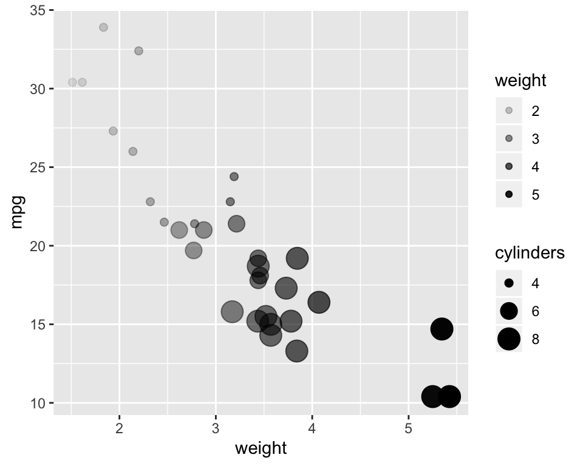

# Examples of other aesthetics

- x-axis: weight
- y-axis: mpg
- color: cylinders
- shape: cylinders

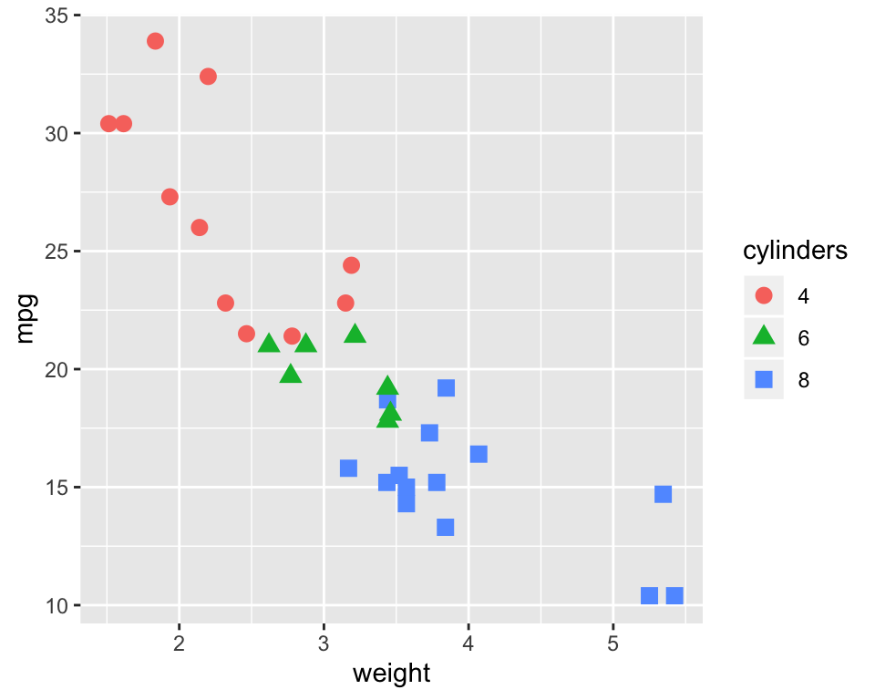

# Agenda for today

- Layers
- Scales
- Facets
- Themes (“non-data ink”)

# Layers: Combining multiple plots into one graphic

We can have more than one **layer** in a graphic.

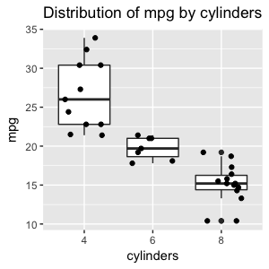

**=**

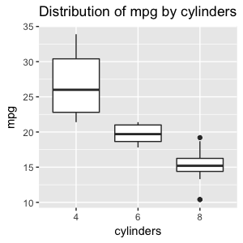

**+**

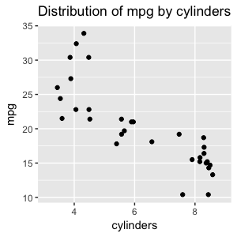

Each layer contains (essentially):

- 1 dataset, 1 **geom**etric object, **aes**thetic mappings

# `ggplot2` code

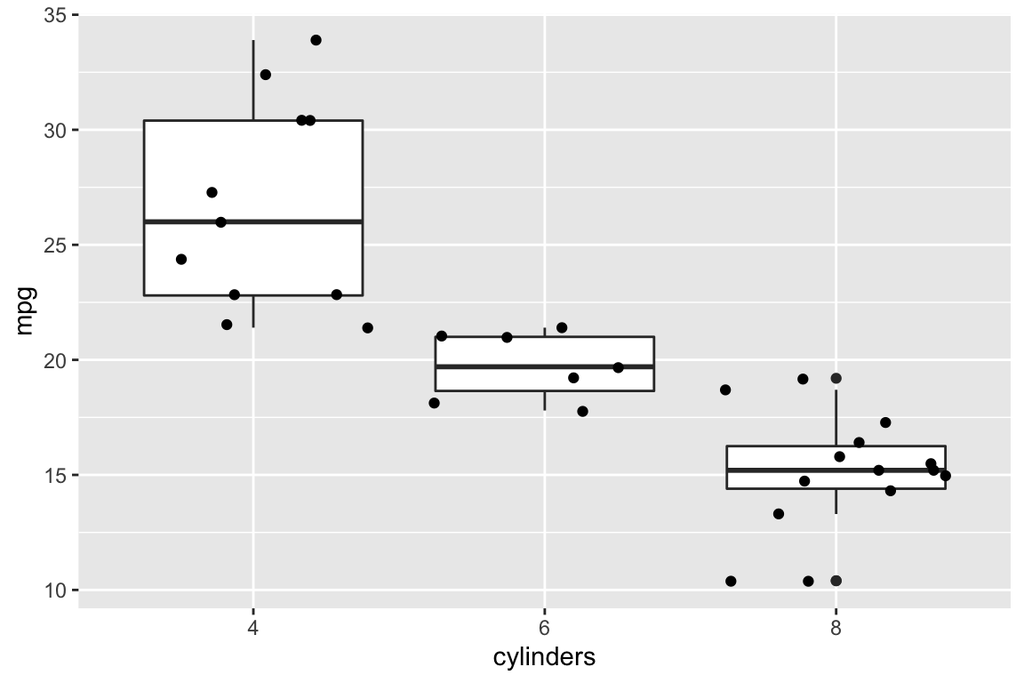

```r
ggplot() +
    geom_boxplot(data = df, mapping = aes(x = cylinders, y = mpg)) +
    geom_point(data = df, mapping = aes(x = cylinders, y = mpg),
               position = "jitter")
```

# `ggplot2` code

When layers share attributes, we only have to type them once:

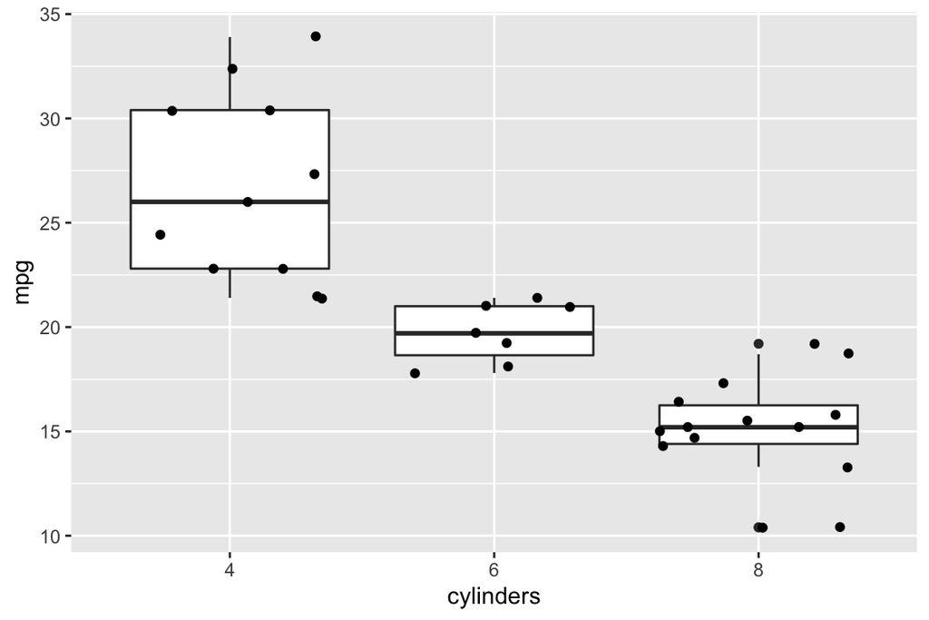

```r
ggplot(data = df, mapping = aes(x = cylinders, y = mpg)) +
    geom_boxplot() +
    geom_point(position = "jitter")
```

# `ggplot2` code

- We can drop `data =` if it is the first argument of `ggplot()`
- We can drop `mapping =` if:
  - it is the second argument of `ggplot()`
  - it is the first argument of a `geom_xx()` function

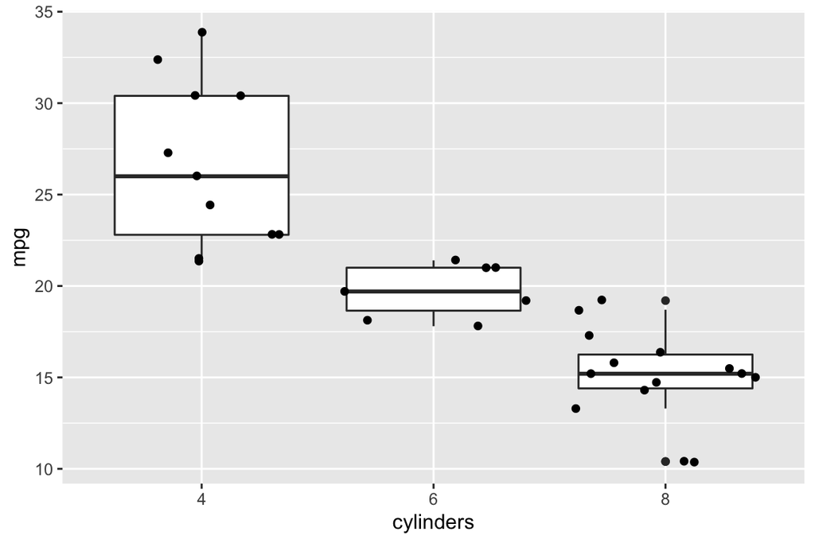

```r
ggplot(df, aes(x = cylinders, y = mpg)) +
    geom_boxplot() +
    geom_point(position = "jitter")
```

# Scales

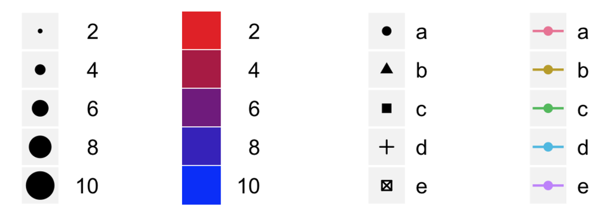

Examples of scales (Source: [A Layered Grammar of Graphics](http://vita.had.co.nz/papers/layered-grammar.pdf))

# Scales example: colors

**Manually chosen colors**

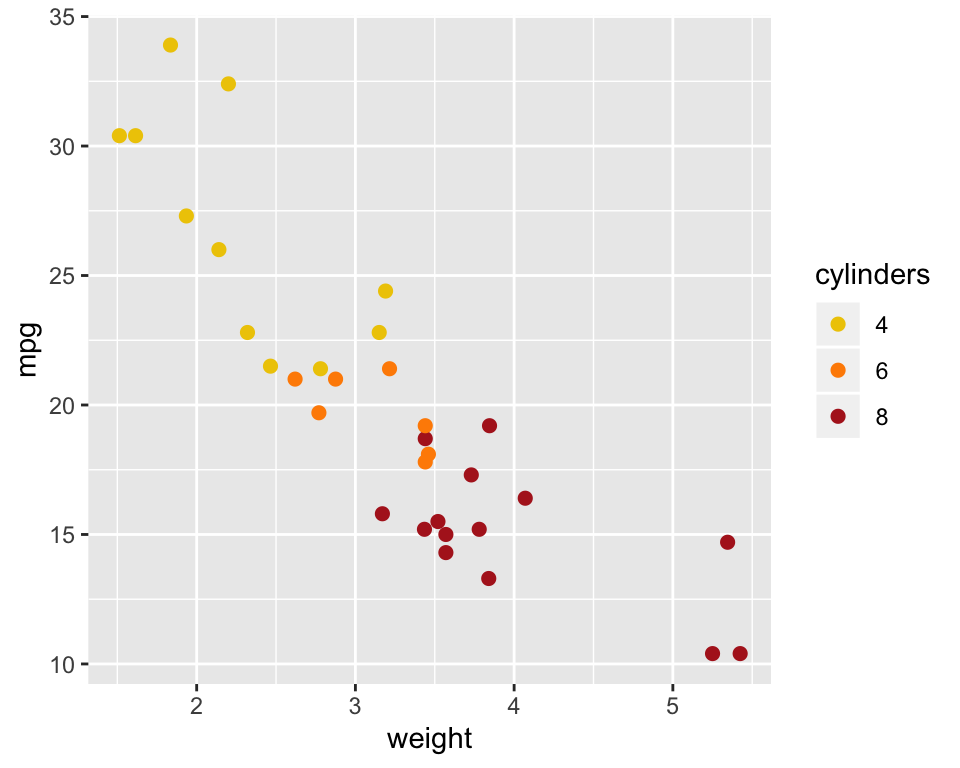

# Scales example: x- & y-axes

**Manually chosen axis limits**

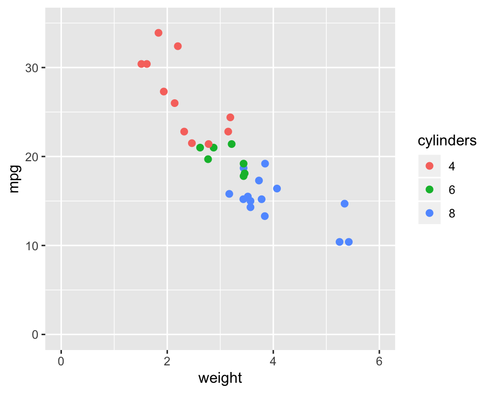

# Facets

- Plotting different parts of our data on different canvases
- Can give a clearer, less cluttered picture
- We can facet by rows and/or columns

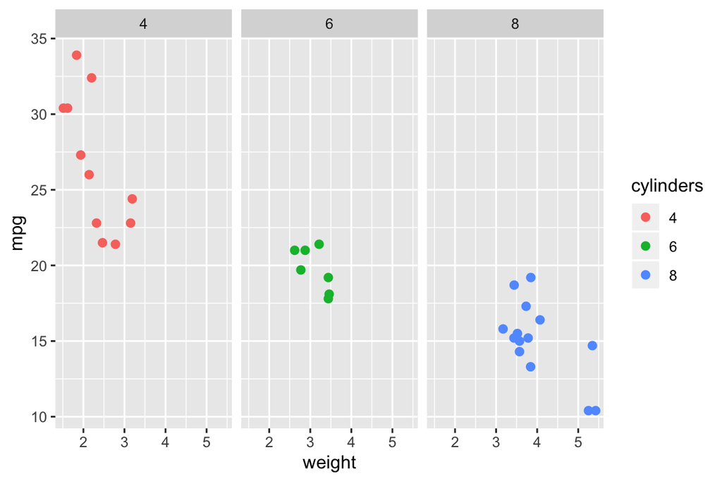

# Themes

Refers to all non-data ink

- Titles, axis ticks & labels, background color, legend, etc.
- Can manually set each item, or use preset themes

**Minimal theme**

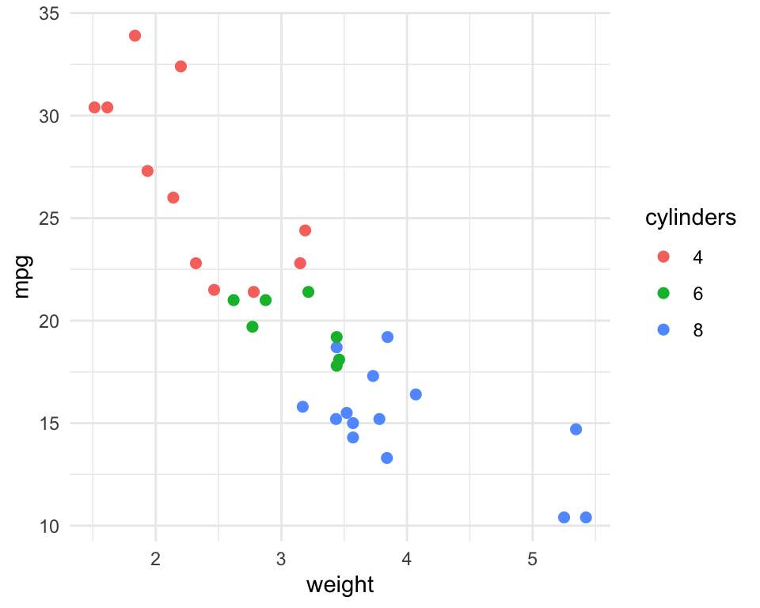

# More pre-set themes

**Classic theme**

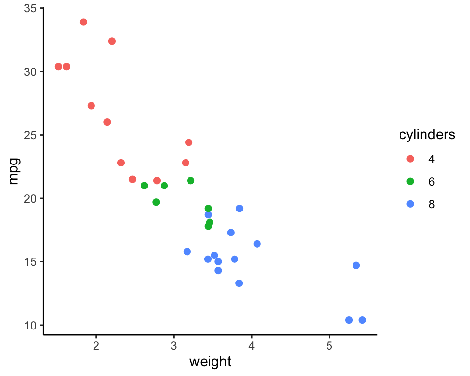

**Dark theme**

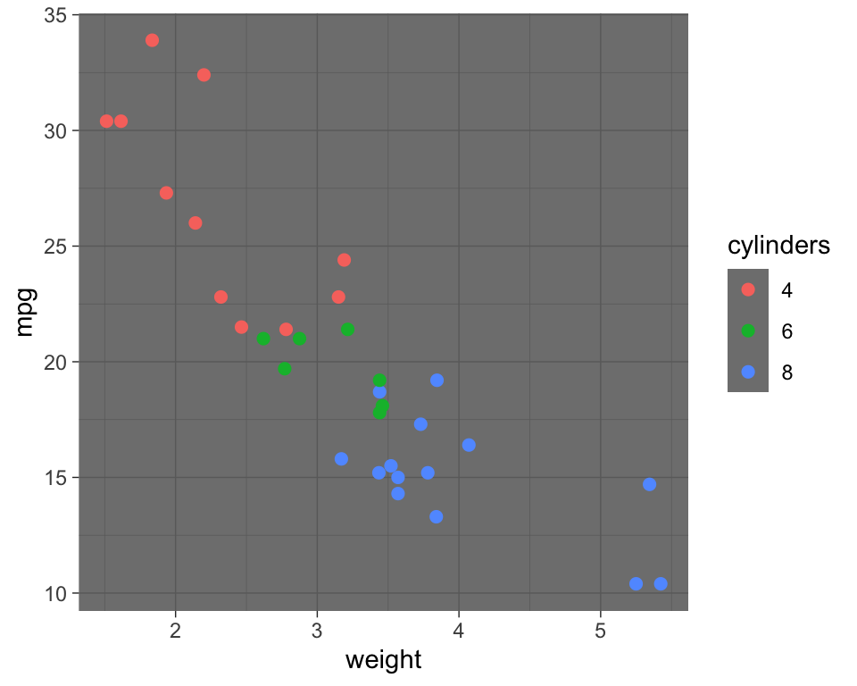

# We’ve only scratched the surface!

[R Graph Gallery](https://www.r-graph-gallery.com/): an excellent source of inspiration and code snippet examples

# Today’s dataset: Diamonds

**What makes an expensive diamond?**

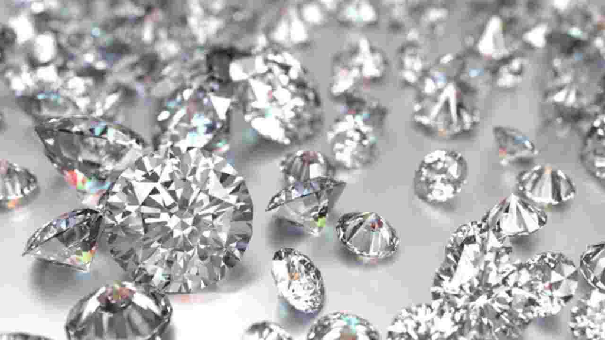

(Source: [USA TODAY](https://www.usatoday.com/videos/tech/science/2018/07/16/-quadrillion-tons-diamonds-hiding-below-earths-surface/36912769/))

**Optional material**

# Full specification of a graphic

One graphic contains:

- 1 or more layers
  - Each layer has 1 dataset, 1 **geom**etric object, **aes**thetic mappings, 1 statistic (default usually ok), 1 position (default usually ok)
- 1 scale for each aesthetic mapping (defaults usually ok)
- 1 coordinate system (default usually ok)
- facet specification (if any)

# Other grammatical elements: statistics

Behind the scenes, R may need to do some transformation on the dataset to make the graphic.

- **Each geometry has a default statistic, usually good enough**

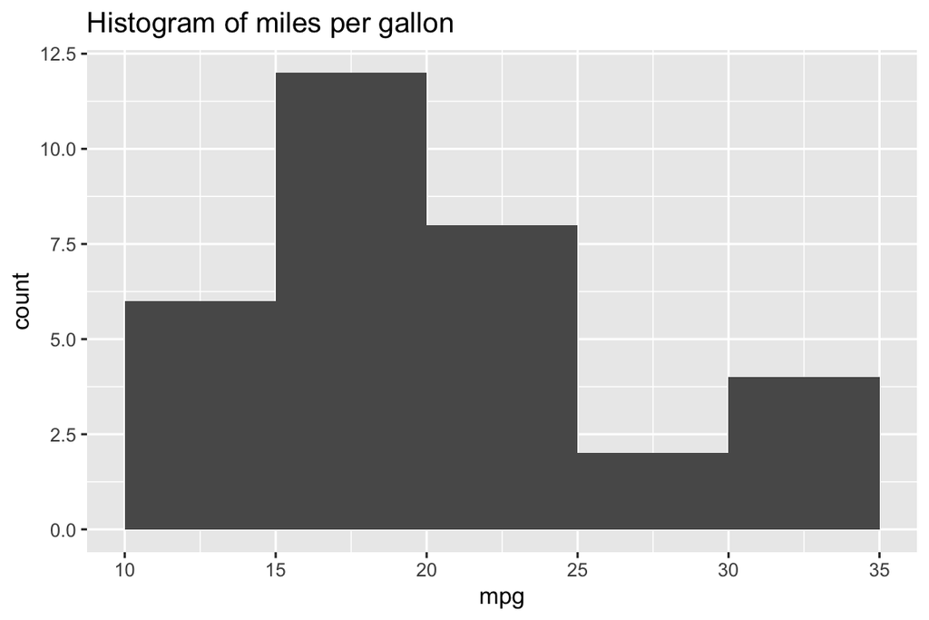

# Other grammatical elements: position

Sometimes we need to tweak the position of the geometric elements because they obscure each other.

- E.g. jitter: randomly shifting points slightly

**Only 9 data points??**

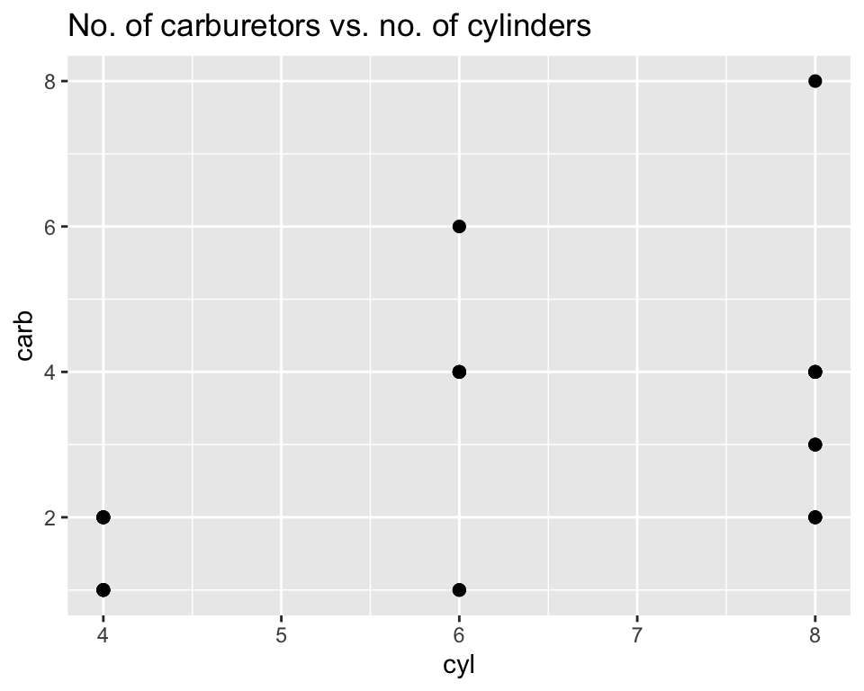

**Much better**

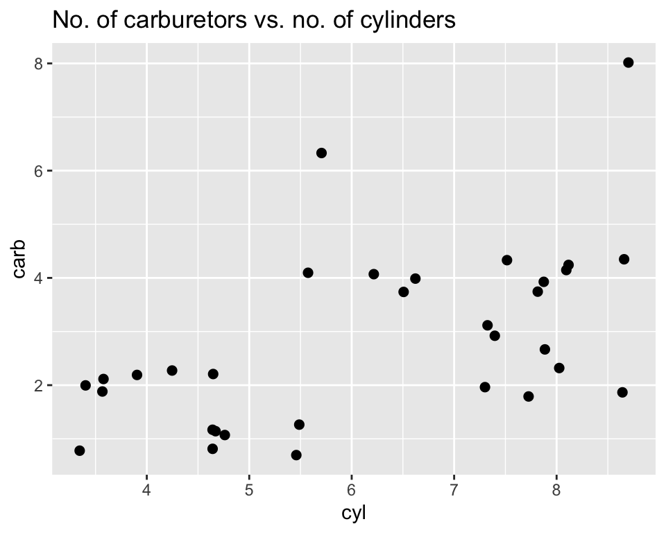

# Shapes in R


# Colors in R

- **By name:** e.g. “blue”, “red”, “black”, “white” (full list [here](http://www.stat.columbia.edu/~tzheng/files/Rcolor.pdf))
- **By RGB value:** e.g. `rgb(0,0,1)`, `rgb(1,0,0)`, `rgb(0,0,0)`, `rgb(1,1,1)`
- **By hexadecimal value:** e.g “#0000FF”, “#FF0000”, “#000000”, “#FFFFFF”

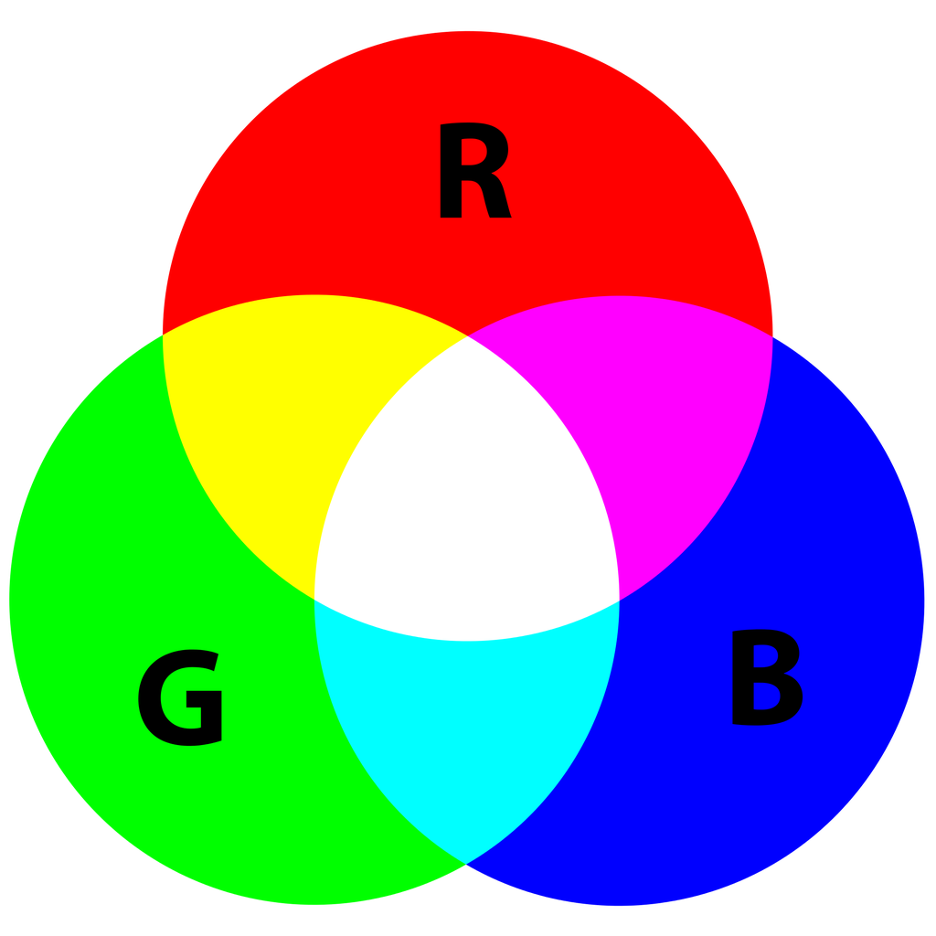

# Color scales in R

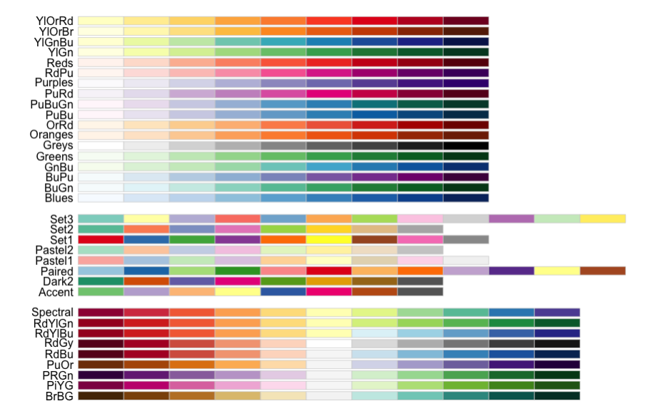